# The Battle of Neighborhoods - Norway

## Introduction

Norway is a Scandinavian country in Northern Europe with an extensive coastline broken by huge fjords and thousands of islands. Norway has a lot to offer - whether you prefer art, entertainment or museums covering everything from the Vikings to seafaring and fishing, or spectacular nature, from its stunning fjords to its majestic mountains and glaciers.

Here we will have a closer look at its two biggest cities - Oslo and Bergen.

- Oslo, the capital of Norway, is located on the southern coast at the head of the Oslofjord. Oslo is a cosmopolitan city with a buzzing restaurant, fashion and art scenes whilst maintaining its refreshing closeness to nature.
- Bergen, located on southwestern coast of Norway, is an ideal starting point for fjord excursions. The city is mostly known for The UNESCO World Heritage site Bryggen, “The Hanseatic Wharf”. Bergen is also a UNESCO City of Gastronomy for fresh seafood being the core of Bergen's cuisine.

Since both of the cities have a lots to offer, we will use Foursquare data and explore the most popular venues in both of these cities in order to help tourists to decide which city would better suits their interests. We will also look at the weather conditions and the number of tourists that have visited Oslo or Bergen so far this year.

1. Data
   1. Population
   2. Weather
   3. Popularity
   4. Venues
2. Methods
   1. Map of Oslo
   2. Map of Bergen
   3. Oslo vs. Bergen
3. Conclusion

## Data

In this project we will compare two biggest cities in Norway - Oslo and Bergen in order to help tourists decide, which city to visit if they get a chance to travel to Norway.

We will compare the weather condition through the year, the number of tourists that have visited Oslo or Bergen so far this year and with the help of Foursqare we will look at the number of restaurants, bars, museums and other activities these cities have to offer.

First, we will need geographical coordinates for Oslo and Bergen to obtain data from Foursquare and create a map for both cities. Then we will use this information to create a map We will use Foursquare location data to explore top 100 venues in Oslo and Bergen within 10 km radius from the cities. We will group these venues and compare them between Oslo and Bergen. We will also create a map vizualizing these venues to get a better idea on their location. The should help us determine, which city has wider options of restaurants, bars, art and museums or outdoors options.

### Population

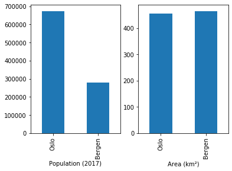

```python
# Create a data frame with population and area size for Oslo and Bergen only.
pop_area = population_df.loc[['Oslo', 'Bergen'],['Population(2017)[2]', 'Area(km²)[3]']]
# Create a barplot and set labels.
fig, axes = plt.subplots(nrows=1, ncols=2)
pop_area['Population(2017)[2]'].plot(ax=axes[0],kind='bar')
axes[0].set_xlabel('Population (2017)')
pop_area['Area(km²)[3]'].plot(ax=axes[1], kind='bar')
axes[1].set_xlabel('Area (km²)')
```

Oslo is the most populus city of Norway, constituting both county and municipality. Oslo occupies the northernmost end of the Oslofjord, surrounded by green hills and mountains in all directions. There are 40 islands within the city and 343 lakes. And even if you visit Oslo in summer, you can still go skiing in the new indoor ski arena. Oslo regularly appears in the top of rankings as a global and most liveable city. Oslo is also amongst the most expensive cities in the world. Neverthless, it offers a world-class architecture, museums, opera and restaurants. Oslo is a very lively party city with a number of bars, concerts and festivals. It definitely has the vibe of a big european city in a smaller package.

Bergen has approximately half the population than Oslo, but covers a large part of the west coast, covering most of the peninsula of Bergenshalvøyen. Bergen is also know as 'the city of seven mountains' as it is surrounded by mountains - Ulriken, Løvstakken, Fløyfjellet, Damsgårdsfjellet, Lyderhorn, Rundemannen, and Sandviksfjellet. Although the mountains are not very high (ranging from 300-650m) they apear majestic as they arise from the sea level. There is an annual event 7-mountain hike, where you walk up and down all seven mountains in one day. Bergen is also known as the gateway to the Fjords because of its location between Hardangerfjord and the Sognefjord which makes it a perfect place to start your trip. Bergen has more urban and local vibe with some of the traditional architecture preserved.

### Weather

Next we looked at the average temperatures and rainfall during the year in Oslo and Bergen. First, we read our data from Wikipedia page for Oslo and Bergen respectively, and we merged them into separate data frames for each category.

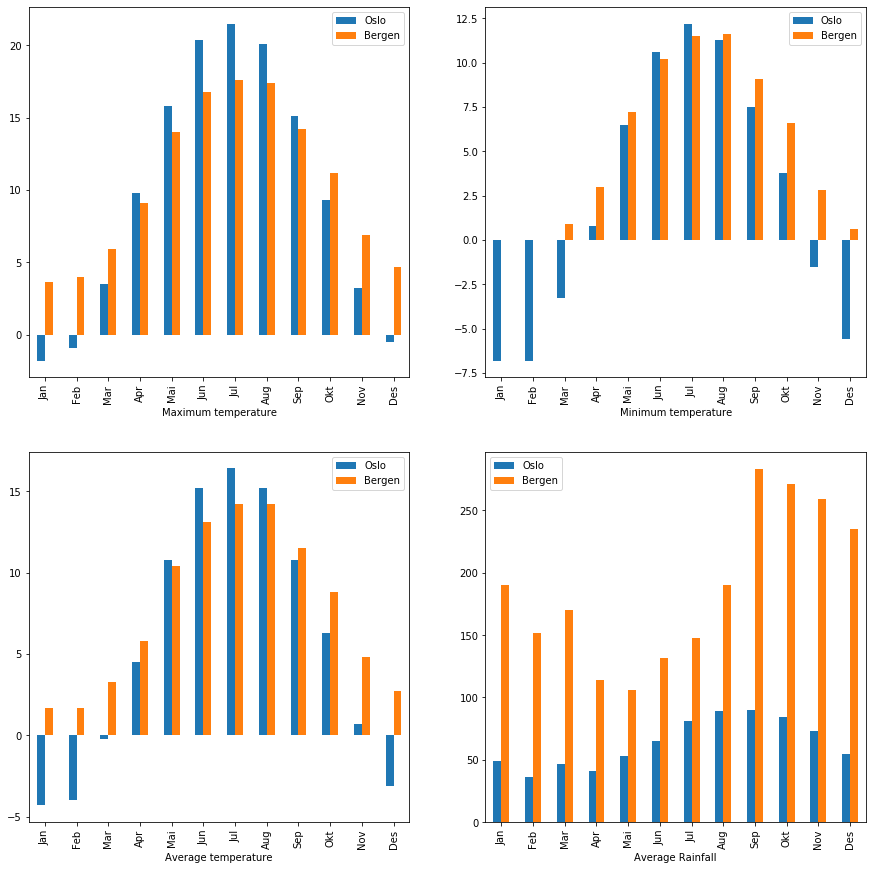

```python
# Create four bar plot representing maximum, average and minimum temperature and rainfall per month in Oslo and Bergen
fig, axes = plt.subplots(nrows=2, ncols=2,figsize=(15,15))
max_temp_df.plot(ax=axes[0,0],kind='bar')
axes[0,0].set_xlabel('Maximum temperature')
min_temp_df.plot(ax=axes[0,1], kind='bar')
axes[0,1].set_xlabel('Minimum temperature')
avg_temp_df.plot(ax=axes[1,0], kind='bar')
axes[1,0].set_xlabel('Average temperature')
rainfall_df.plot(ax=axes[1,1], kind='bar')
axes[1,1].set_xlabel('Average Rainfall')
```

Oslo has a humid continental climate, but due to its location winters are less cold than at same latitude areas. On the other hand, Bergen has an oceanic climate. The weather is milder than in Oslo, with temperatures rarely dropping below 0 °C in winter. However, Bergen is considered the rainiest city in Europe, with almost 200 rainy days per year. The weather in Bergen might change very quickly so be sure to have umbrella always with you.

### Popularity

From the Norwegian statistics page we downloaded data about number of guest nights so far this year. (Please, consider that current pendemic restrictions might influenced these numbers.)

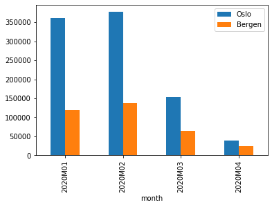

```python
# Merge the two data frames for Oslo and Bergen together
result_accom = pd.concat([oslo_accom,bergen_accom], axis=1, sort=False)
result_accom = result_accom.astype(str).astype(int)
# Plot
result_accom.plot(kind="bar")
```

Oslo, as the capital of Norway, is much more dynamic city with lots of visit, whether it is for business or leisure. Bergen is a popular touristic destination too, for its close proximity to fjords and it is one of Europe's largest cruise ship ports, which wouldn't show in this chart as it only accounts for guest nights at hotels and similar accommodation facilities.

### Venues

Next, using Forsquare we will compare the number of popular venues these cities have to offer.  
Firts we will need to obrtain geographical coordinates for Oslo and Bergen.

```python
address_oslo = 'Oslo, Norway'
geolocator_oslo = Nominatim(user_agent="oslo_explorer")
location_oslo = geolocator_oslo.geocode(address_oslo)
latitude_oslo = location_oslo.latitude
longitude_oslo = location_oslo.longitude
print('The geograpical coordinate of Oslo are {}, {}.'.format(latitude_oslo, longitude_oslo))
```

```
The geograpical coordinate of Oslo are 59.9133301, 10.7389701.
```

Obtain the geographical coordinates for Bergen, Norway

```python
address_bergen = 'Bergen, Norway'
geolocator_bergen = Nominatim(user_agent="bergen_explorer")
location_bergen = geolocator_bergen.geocode(address_bergen)
latitude_bergen = location_bergen.latitude
longitude_bergen = location_bergen.longitude
print('The geograpical coordinate of Bergen are {}, {}.'.format(latitude_bergen, longitude_bergen))
```

```
The geograpical coordinate of Bergen are 60.3943055, 5.3259192.
```

```python
# @hidden_cell
CLIENT_ID = 'XXXX' # your Foursquare ID
CLIENT_SECRET = 'XXXXX' # your Foursquare Secret
VERSION = '20180605' # Foursquare API version
```

```python
search_outdoor = 'outdoor fun'
search_nightlife = 'nightlife'
search_food = 'food'
search_fun = 'fun'
LIMIT = 100
search_queries = {'nightlife':1, 'food':2, 'fun':3, 'outdoor fun':4}
```

```python
def getVenues(search_queries, latitude, longitude, radius):

    final_df = []

    for query in search_queries:
        print (query)

        # create the API request URL
        url = 'https://api.foursquare.com/v2/venues/explore?client_id={}&client_secret={}&ll={},{}&v={}&query={}&radius={}&limit={}'.format(
            CLIENT_ID,
            CLIENT_SECRET,
            latitude,
            longitude,
            VERSION,
            query,
            radius,
            LIMIT)

        # make the GET request
        results = requests.get(url).json()["response"]['groups'][0]['items']
        dataframe = json_normalize(results) #flatten JSON

        # filter columns
        filtered_columns = ['venue.name', 'venue.categories', 'venue.location.lat', 'venue.location.lng']
        dataframe_filtered = dataframe.loc[:, filtered_columns]

        # filter the category for each row
        dataframe_filtered['venue.categories'] = dataframe_filtered.apply(get_category_type, axis=1)

        # clean columns
        dataframe_filtered.columns = [col.split(".")[-1] for col in dataframe_filtered.columns]

        # insert group column
        dataframe_filtered.insert(4,'group', search_queries[query])

        # append to final data frame
        final_df.append(dataframe_filtered)

    final_df = pd.concat(final_df)
    return(final_df)

def top100Venues(latitude, longitude, radius, limit):

    url = 'https://api.foursquare.com/v2/venues/explore?&client_id={}&client_secret={}&v={}&ll={},{}&radius={}&limit={}'.format(
        CLIENT_ID,
        CLIENT_SECRET,
        VERSION,
        latitude,
        longitude,
        radius,
        limit)
    results = requests.get(url).json()['response']['groups'][0]['items']
    top_venues = json_normalize(results) # flatten JSON

    # filter columns
    filtered_columns = ['venue.name', 'venue.categories', 'venue.location.lat', 'venue.location.lng']
    top_venues = top_venues.loc[:, filtered_columns]

    # filter the category for each row
    top_venues['venue.categories'] = top_venues.apply(get_category_type, axis=1)

    # clean columns
    top_venues.columns = [col.split(".")[-1] for col in top_venues.columns]

    return(top_venues)



def get_category_type(row):
    try:
        categories_list = row['categories']
    except:
        categories_list = row['venue.categories']

    if len(categories_list) == 0:
        return None
    else:
        return categories_list[0]['name']


def groupVenues(venues):

    groups = []
    for venue in venues['categories']:
        if re.search('Bar', venue, re.IGNORECASE) or re.search('Brewery',venue,re.IGNORECASE) or re.search('Beer',venue,re.IGNORECASE) or re.search('Pub',venue,re.IGNORECASE):
            groups.append('Bars')
        elif re.search('Restaurant', venue, re.IGNORECASE) or re.search('Pizza',venue, re.IGNORECASE) or re.search('Place', venue, re.IGNORECASE) or re.search('Food', venue, re.IGNORECASE) or re.search('Burger',venue,re.IGNORECASE) or re.search('Burrito',venue,re.IGNORECASE) or re.search('Steakhouse', venue, re.IGNORECASE) or re.search('Market', venue, re.IGNORECASE):
            groups.append('Restaurants')
        elif re.search('Coffee', venue,re.IGNORECASE) or re.search('Bakery', venue, re.IGNORECASE) or re.search('Café', venue, re.IGNORECASE):
            groups.append('Coffee shops')
        elif re.search('Museum',venue,re.IGNORECASE) or re.search('Theater',venue,re.IGNORECASE) or re.search('Gallery',venue,re.IGNORECASE) or re.search('Opera',venue,re.IGNORECASE) or re.search('Castle',venue,re.IGNORECASE) or re.search('Exhibit', venue,re.IGNORECASE) or re.search('Neighborhood', venue, re.IGNORECASE) or re.search('Palace', venue, re.IGNORECASE):
            groups.append('Art&Culture')
        elif re.search('Shop', venue,re.IGNORECASE) or re.search('store',venue, re.IGNORECASE):
            groups.append('Shopping')
        elif re.search('Club', venue,re.IGNORECASE) or re.search('Venue', venue, re.IGNORECASE) or re.search('Nightlife',venue,re.IGNORECASE) or re.search(' Entertainment',venue,re.IGNORECASE):
            groups.append('Nightlife')
        elif re.search('Hotel', venue, re.IGNORECASE):
            groups.append('Hotels')
        elif re.search('Park',venue, re.IGNORECASE) or re.search('Road', venue, re.IGNORECASE) or re.search('Fountain',venue, re.IGNORECASE) or re.search('Plaza', venue, re.IGNORECASE) or re.search('Scenic',venue,re.IGNORECASE) or re.search('Garden',venue,re.IGNORECASE) or re.search('Mountain',venue,re.IGNORECASE) or re.search('Trail',venue,re.IGNORECASE) or re.search('Aquarium',venue,re.IGNORECASE) or re.search('Stadium',venue,re.IGNORECASE) or re.search('Pool', venue, re.IGNORECASE) or re.search('Bathing', venue, re.IGNORECASE) or re.search('Gym', venue, re.IGNORECASE) or re.search('Waterfront', venue, re.IGNORECASE):
            groups.append('Outdoors')
        else:
            groups.append('Empty')
    venues["Group"] = groups
    venues = venues.drop(columns=['lat', 'lng'])
    return(venues)
```

#### Oslo

First, we will use our search queries to obtain 100 venues from each query.

```python
map_clusters = folium.Map(location=[latitude_oslo, longitude_oslo], zoom_start=11)

x = np.arange(4)
ys = [i + x + (i*x)**2 for i in range(4)]
colors_array = cm.rainbow(np.linspace(0, 1, len(ys)))
rainbow = [colors.rgb2hex(i) for i in colors_array]

# add markers to the map
markers_colors = []
for lat, lon, cat, group in zip(venues_oslo['lat'], venues_oslo['lng'], venues_oslo['categories'], venues_oslo['group']):
    label = folium.Popup(str(cat) + ' Cluster ' + str(group), parse_html=True)
    folium.CircleMarker(
        [lat, lon],
        radius=5,
        popup=label,
        color=rainbow[group-1],
        fill=True,
        fill_color=rainbow[group-1],
        fill_opacity=0.7).add_to(map_clusters)

map_clusters
```

Make this Notebook Trusted to load map: File -> Trust Notebook

[interactive chart not shown]

#### Bergen

Now we search for our venues in Bergen and vizualise them using folium.Map

(Please note that since Bergen is a smaller city, we got less than 100 hits in our search queries.)

```python
map_clusters = folium.Map(location=[latitude_bergen, longitude_bergen], zoom_start=11)

x = np.arange(4)
ys = [i + x + (i*x)**2 for i in range(4)]
colors_array = cm.rainbow(np.linspace(0, 1, len(ys)))
rainbow = [colors.rgb2hex(i) for i in colors_array]

# add markers to the map
markers_colors = []
for lat, lon, cat, group in zip(venues_bergen['lat'], venues_bergen['lng'], venues_bergen['categories'], venues_bergen['group']):
    label = folium.Popup(str(cat) + ' Cluster ' + str(group), parse_html=True)
    folium.CircleMarker(
        [lat, lon],
        radius=5,
        popup=label,
        color=rainbow[group-1],
        fill=True,
        fill_color=rainbow[group-1],
        fill_opacity=0.7).add_to(map_clusters)

map_clusters
```

Make this Notebook Trusted to load map: File -> Trust Notebook

[interactive chart not shown]

#### Oslo vs. Bergen

Now, we want to compare the options in Oslo and Bergen when it comes to dinning, nightlife, outdoors activities, art and museums. So we ran a query for top100 most popular places in Oslo and Bergen and groupped them into broader categories to get a better overview.

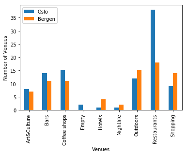

```python
# Create a plot
venues_merged.plot(kind='bar')
plt.legend(['Oslo', 'Bergen'])
plt.xlabel('Venues')
plt.ylabel('Number of Venues')
```

## Conclusion

In this projects we have compared two of the Norway's biggest cities - Oslo and Bergen. Oslo is a modern metropolitan city with a fast growing neighborhoods offering beautiful architecture, amazing restaurants and bars and broad variety of galleries and museums. At the same time it's close proximity to the nature can appease everyone who would like to get the best of both worlds. Bergen is a smaller, more cozy city with its signature architecture and well preserved buildings. It is surrounded by mountains which offer endless number of hike routes and spectacular views. Bergen is also one of the rainiest cities in Europe, but hopefully a bit of rain doesn't discourage you. Whichever city appeals to you the most, Norway is a beautiful country with stunning nature and it is definitely worth the visit.

```python
from IPython.display import HTML
```

```python
from IPython.display import HTML

HTML('''<script>
code_show=true;
function code_toggle() {
 if (code_show){
 $('div.input').hide();
 } else {
 $('div.input').show();
 }
 code_show = !code_show
}
$( document ).ready(code_toggle);
</script>
<form action="javascript:code_toggle()"><input type="submit" value="Click here to toggle on/off the raw code."></form>''')
```